# Division III Baseball Batting Statistics as Predictors for Runs Scored

Hardy Smith and Will Guzman

2023-04-24

# Abstract

In baseball, the outcome of the game is determined by the team that scores the most runs. For decades, coaches, players, and fans have argued which batting statistic is the most important to the total number of runs a team scores. In this experiment, we looked at which batting statistics had the biggest impact on the total runs scored. To do this, we ran linear regression models to see which had the strongest correlation. By using data from Division III baseball to model these relationships, more specifically data from the Southern Athletic Association (Rhodes’ conference) and the New England Small College Conference, it allowed us to see concrete relationships between these variables and bring insight to this heavily debated subject.

# Introduction and Terminology

What is the most important batting statistic in baseball? Over the past two decades, with the takeover and growing prominence of data analytics in the sport of baseball, teams have researched and argued which statistic most efficiently and abundantly indicates more runs scored.

We wanted to find out, in Division III baseball, which batting statistic: batting average (AVG), on-base percentage (OBP), or slugging percentage (SLGP), has the greatest relationship with players scoring more runs. To find the answer to this question, we looked at the relationship (through multiple linear regression models) between a players’ total runs scored and each of these statistics to see which had the strongest correlation.

Before we get into our data, it is important to define some key variables in our experiment. First looking at our response variables which is a players’ total runs scored. Runs are measured in increments of 1, increasing by 1 every time a player crosses home plate, thus, the range of possible values will be positive integers, including 0, to some number less than 100; considering the length of the Division III baseball season, scoring more than 100 is nearly impossible. This value will likely have an average somewhere around 20 runs for Division III baseball players with recorded statistics. Next looking at our explanatory variables which are a player’s batting average (AVG), on-base percentage (OBP), and slugging percentage (SLGP). A player’s batting average is a quantitative value, measured as a percentage, calculated by dividing a player’s hits by his total at-bats (located under the AVG column). Slugging Percentage is also quantitative value, measured as a percentage, that represents the total number of bases a player records per at-bat, essentially equating to being a “big hitter” if you have a higher SLGP. The exact formula for slugging percentage is: (1B + 2Bx2 + 3Bx3 + HRx4)/AB (located under SLGP column). Lastly, On-Base Percentage, a quantitative value, measured as a percentage, that represents the percentage that a player gets on base in any form, including hit by pitch or base on balls (located under OBP column). The full formula is as follows (Hits + Walks + Hit by Pitch) / (At Bats + Walks + Hit by Pitch + Sacrifice Flies)

# Data and Hypothesis

We collected our data from the Southern Athletic Association and New England Small College Athletic Conference–the two conferences keep archives of BA, OBP, and SLGP dating back several years. We compiled each of those statistics from the 2022 season from every player on each team’s roster from those archives and put them into an Excel File to use for our modeling and calculations. These statistics can be found on each conference’s athletic website.The sample will be the baseball players in the NESCAC and SAA with recorded batting statistics from the 2022 baseball season. This came out to be 338 observational units; however, after cleaning and wrangling our data, we ended up with a sample of 266. We are hoping to generalize for all Division III baseball players, and with 374 Division III baseball teams carrying an average of 34 players, we are generalizing to a population of around 12,716 individuals. We hypothesize that a player’s on-base percentage will be the batting statistic that has the strongest relationship with their total runs scored. As mentioned earlier, we are using multiple linear regression models to determine this statistic. In addition to this, we will look at how the relationships of the data are similar or differ between conferences to see if the relationships hold across conferences.

```r
library(ggplot2)
library(tidyverse)
library(Stat2Data)
library(skimr)
library(mosaic)
```

## Data Wrangling

Below is our data wrangling and how we cleaned the original data

```r
d3Baseball <- read.csv("Project_Data copy.csv")
view(d3Baseball)
```

Making column titles callable

```r
 colnames(d3Baseball)[colnames(d3Baseball) %in% c("SLG.", "OB.")] <- c("SLGP", "OBP")
```

Cleaning out erroneous rows

```r
d3BaseballClean <- d3Baseball %>%
  filter(!row_number() %in% c(168, 175))
view(d3BaseballClean)
```

Summarizing data

```r
skim(d3BaseballClean)
```

Data summary

| Name | d3BaseballClean |
| --- | --- |
| Number of rows | 336 |
| Number of columns | 5 |
| _______________________ |  |
| Column type frequency: |  |
| character | 1 |
| numeric | 4 |
| ________________________ |  |
| Group variables | None |

**Variable type: character**

| skim_variable | n_missing | complete_rate | min | max | empty | n_unique | whitespace |
| --- | --- | --- | --- | --- | --- | --- | --- |
| Team | 0 | 1 | 3 | 10 | 0 | 18 | 0 |

**Variable type: numeric**

| skim_variable | n_missing | complete_rate | mean | sd | p0 | p25 | p50 | p75 | p100 | hist |
| --- | --- | --- | --- | --- | --- | --- | --- | --- | --- | --- |
| AVG | 0 | 1 | 0.27 | 0.10 | 0.0 | 0.21 | 0.27 | 0.33 | 0.67 | ▂▆▇▁▁ |
| R | 0 | 1 | 15.36 | 14.03 | 0.0 | 3.00 | 12.00 | 23.00 | 64.00 | ▇▅▂▁▁ |
| SLGP | 0 | 1 | 0.38 | 0.16 | 0.0 | 0.29 | 0.38 | 0.48 | 1.00 | ▂▇▇▁▁ |
| OBP | 0 | 1 | 0.37 | 0.10 | 0.1 | 0.31 | 0.38 | 0.43 | 1.00 | ▂▇▂▁▁ |

Visualizing data

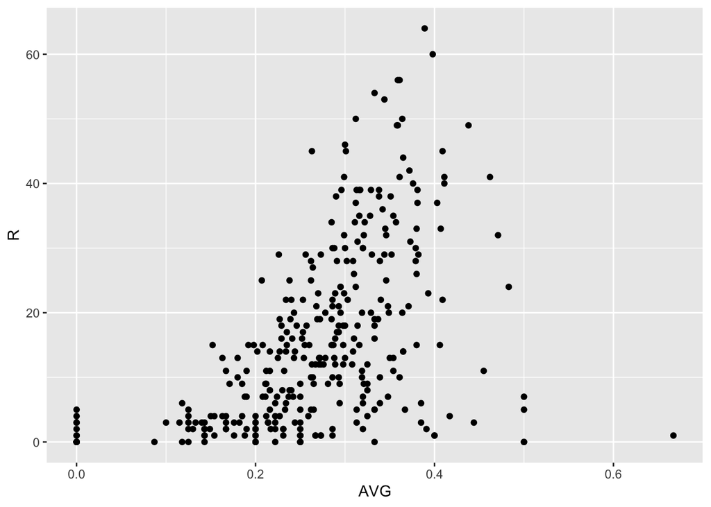

```r
ggplot(data=d3BaseballClean) + geom_point(aes(y=R, x=AVG))
```

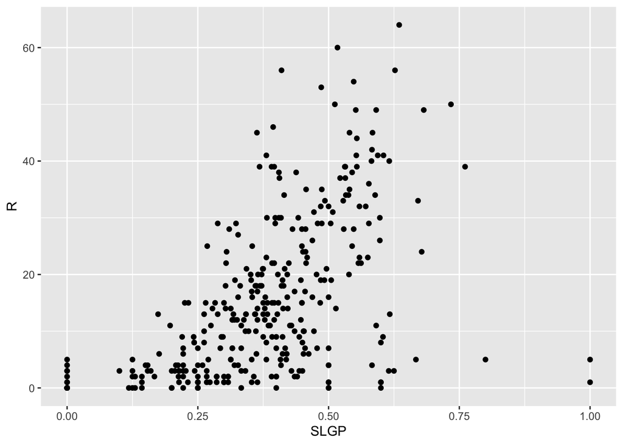

```r
ggplot(data=d3BaseballClean) + geom_point(aes(y=R, x=SLGP))
```

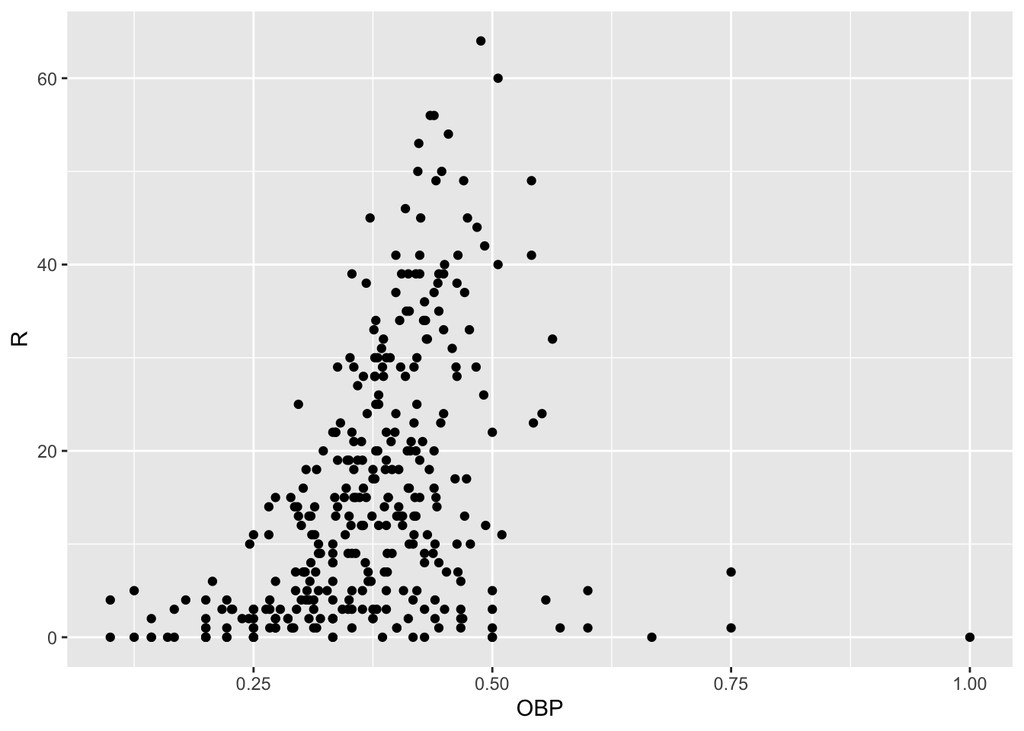

```r
ggplot(data=d3BaseballClean) + geom_point(aes(y=R, x=OBP))
```

Checking outliers

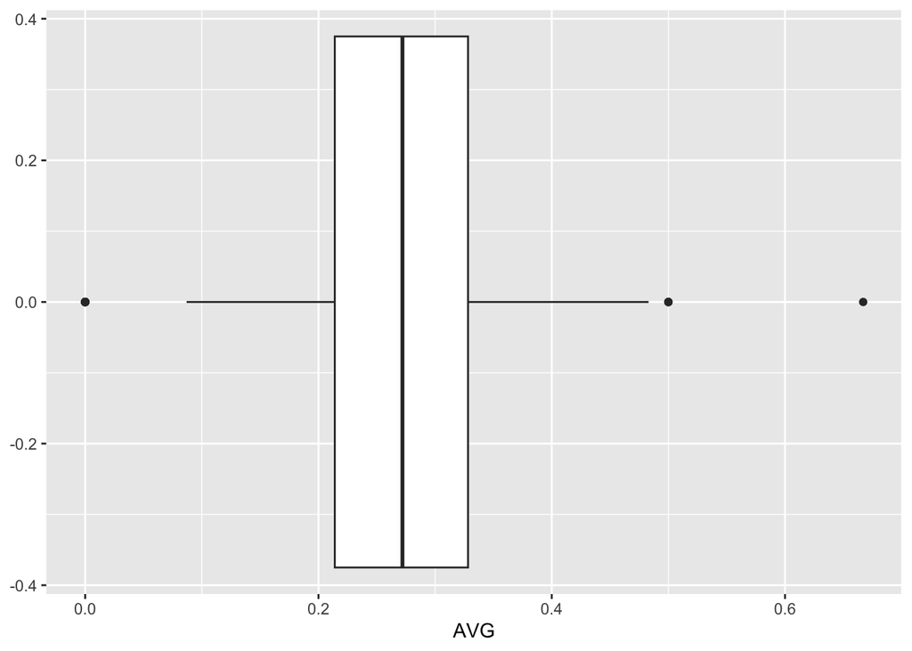

```r
ggplot(d3BaseballClean, aes(x = AVG)) + geom_boxplot()
```

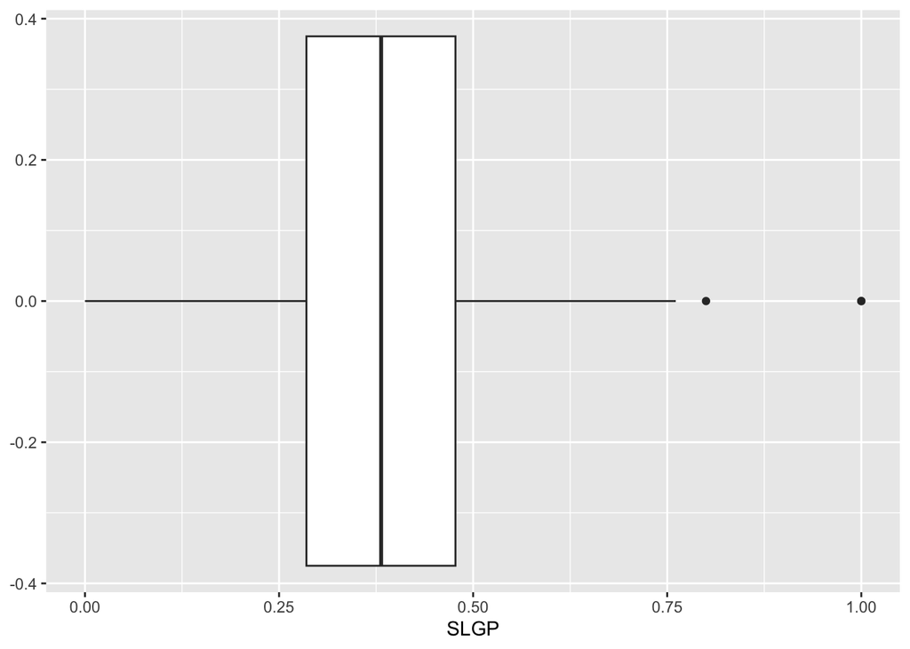

```r
ggplot(d3BaseballClean, aes(x = SLGP)) + geom_boxplot()
```

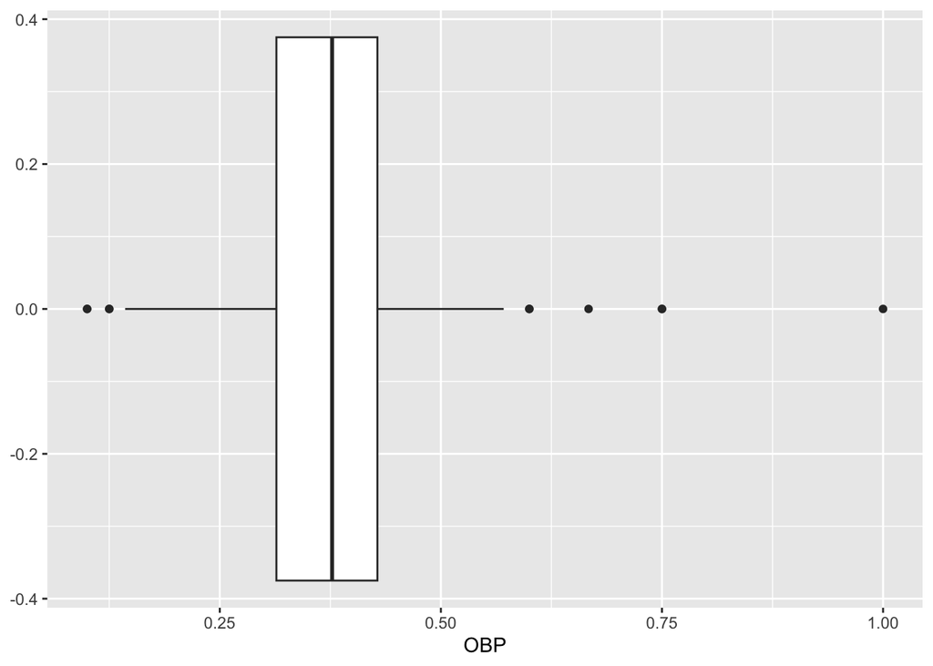

```r
ggplot(d3BaseballClean, aes(x = OBP)) + geom_boxplot()
```

Here we are removing outliers based off the visualization and boxplots. Several players in the data set had skewed statistics. For example, if a player had few at bats, they might have had an on base percentage of 100%, but scored 0 runs. This is misleading, so we filtered out abnormally low or abnormally high batting statistics that may be indicative of having had few at bats.

```r
d3BaseballClean <- d3BaseballClean %>%
  filter(AVG <= 0.49 & AVG >= 0.1, SLGP <= 0.75 & SLGP >= 0.25, OBP <= 0.59 & OBP >= 0.21)
```

Transforming data

```r
d3BaseballClean <- d3BaseballClean %>%
  mutate(
    AVG = sqrt(AVG),
    SLGP = sqrt(SLGP),
    OBP = sqrt(OBP)
    )
```

Summarizing filtered data

```r
skim(d3BaseballClean)
```

Data summary

| Name | d3BaseballClean |
| --- | --- |
| Number of rows | 266 |
| Number of columns | 5 |
| _______________________ |  |
| Column type frequency: |  |
| character | 1 |
| numeric | 4 |
| ________________________ |  |
| Group variables | None |

**Variable type: character**

| skim_variable | n_missing | complete_rate | min | max | empty | n_unique | whitespace |
| --- | --- | --- | --- | --- | --- | --- | --- |
| Team | 0 | 1 | 3 | 10 | 0 | 18 | 0 |

**Variable type: numeric**

| skim_variable | n_missing | complete_rate | mean | sd | p0 | p25 | p50 | p75 | p100 | hist |
| --- | --- | --- | --- | --- | --- | --- | --- | --- | --- | --- |
| AVG | 0 | 1 | 0.54 | 0.06 | 0.38 | 0.50 | 0.54 | 0.58 | 0.69 | ▁▅▇▅▁ |
| R | 0 | 1 | 18.41 | 14.01 | 0.00 | 7.00 | 15.00 | 28.00 | 64.00 | ▇▆▃▂▁ |
| SLGP | 0 | 1 | 0.64 | 0.08 | 0.50 | 0.59 | 0.64 | 0.70 | 0.86 | ▅▇▆▅▁ |
| OBP | 0 | 1 | 0.62 | 0.06 | 0.47 | 0.58 | 0.62 | 0.66 | 0.76 | ▂▅▇▇▂ |

Visualizing the filtered data

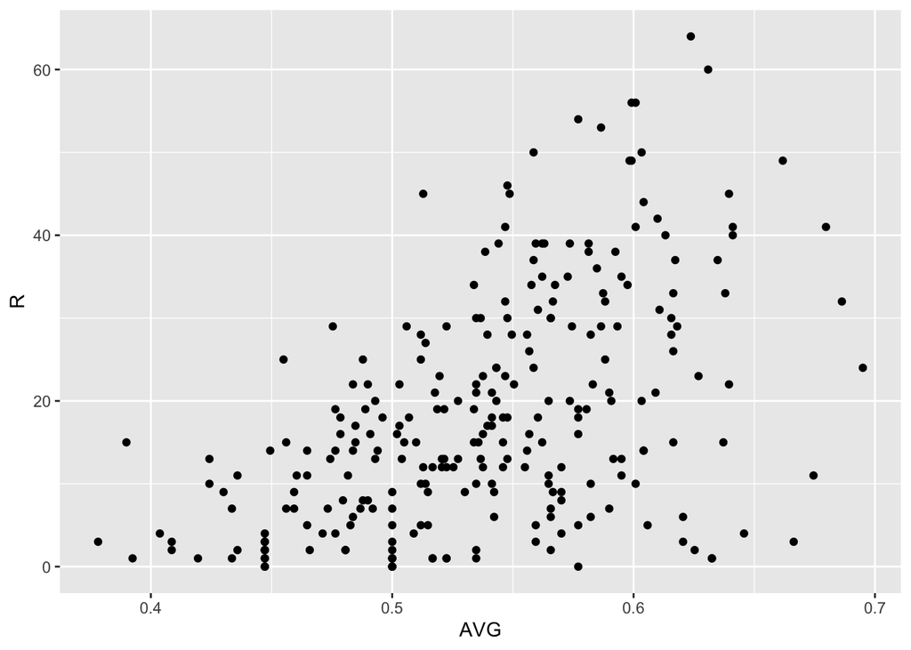

```r
ggplot(data=d3BaseballClean) + geom_point(aes(y=R, x=AVG))
```

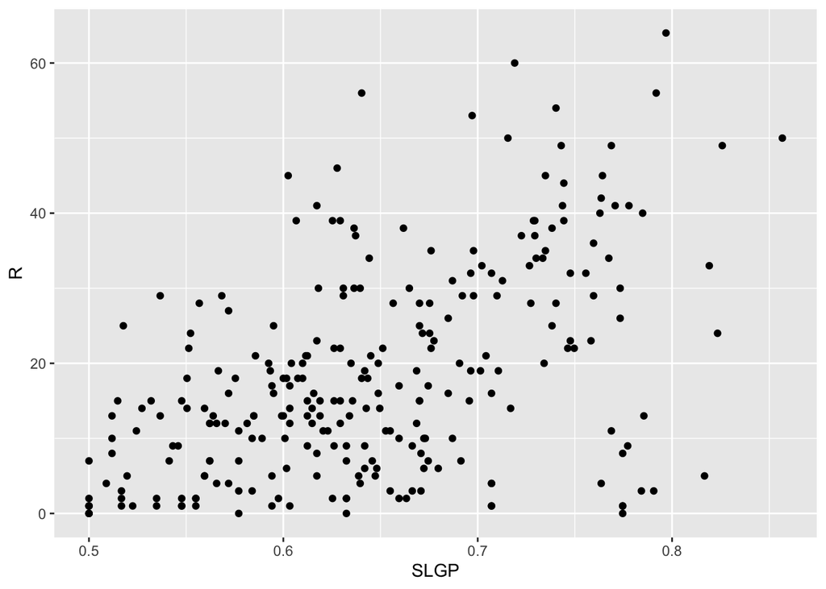

```r
ggplot(data=d3BaseballClean) + geom_point(aes(y=R, x=SLGP))
```

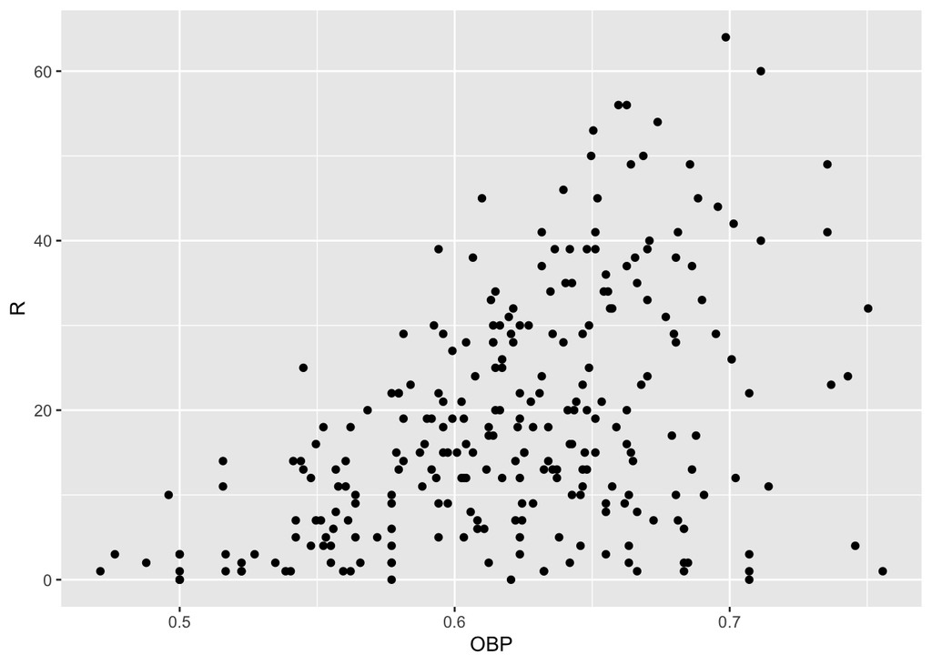

```r
ggplot(data=d3BaseballClean) + geom_point(aes(y=R, x=OBP))
```

## Model

Here we define a multiple linear regression model for the data set containing data from 266 players in both the SAA and NESCAC.

```r
model <- lm(R~AVG+SLGP+OBP, data = d3BaseballClean)
```

Checking diagnostics

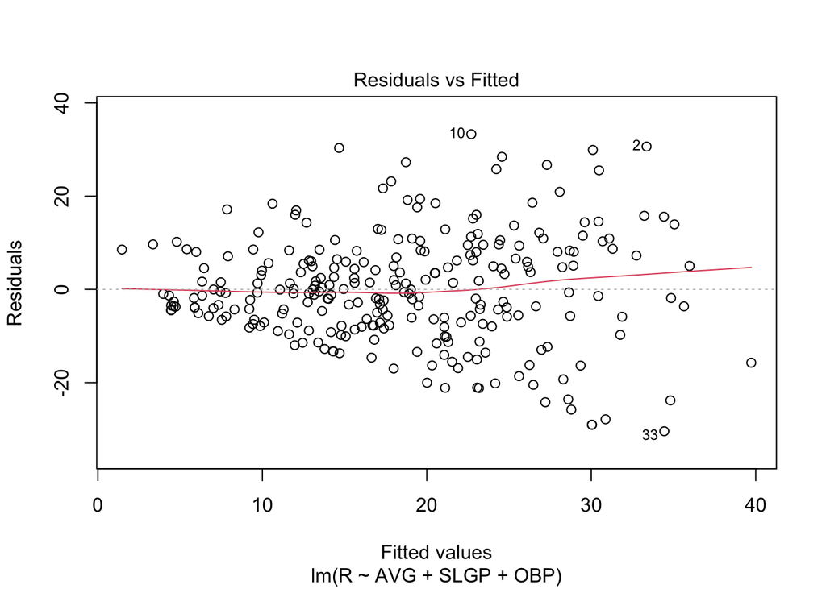

```r
plot(model, which = 1)
```

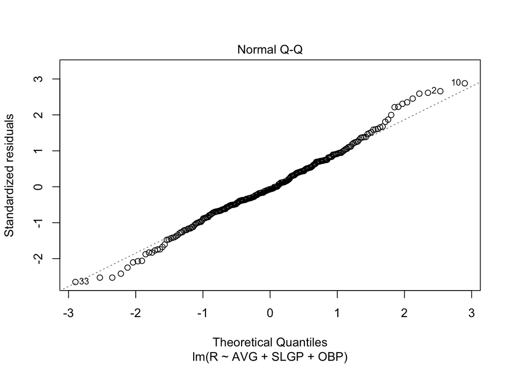

```r
plot(model, which = 2)
```

```r
plot(model, which = 3)
```

[output not shown]

Model summary

```r
summary(model)
```

```
##
## Call:
## lm(formula = R ~ AVG + SLGP + OBP, data = d3BaseballClean)
##
## Residuals:
##     Min      1Q  Median      3Q     Max
## -30.439  -7.099  -0.802   7.328  33.293
##
## Coefficients:
##             Estimate Std. Error t value Pr(>|t|)
## (Intercept)  -63.956      8.272  -7.732 2.28e-13 ***
## AVG           45.705     20.129   2.271   0.0240 *
## SLGP          52.522     11.550   4.547 8.32e-06 ***
## OBP           38.594     19.693   1.960   0.0511 .
## ---
## Signif. codes:  0 '***' 0.001 '**' 0.01 '*' 0.05 '.' 0.1 ' ' 1
##
## Residual standard error: 11.63 on 262 degrees of freedom
## Multiple R-squared:  0.319,  Adjusted R-squared:  0.3112
## F-statistic: 40.91 on 3 and 262 DF,  p-value: < 2.2e-16
```

## Splitting the conferences

```r
SAA <- filter(d3BaseballClean, Team == "BSC" | Team == "Berry" | Team == "Rhodes" | Team == "Millsaps" | Team == "Hendrix" | Team == "Oglethorpe" | Team == "Centre" | Team == "Sewanee")
view(SAA)
```

Visualizing data

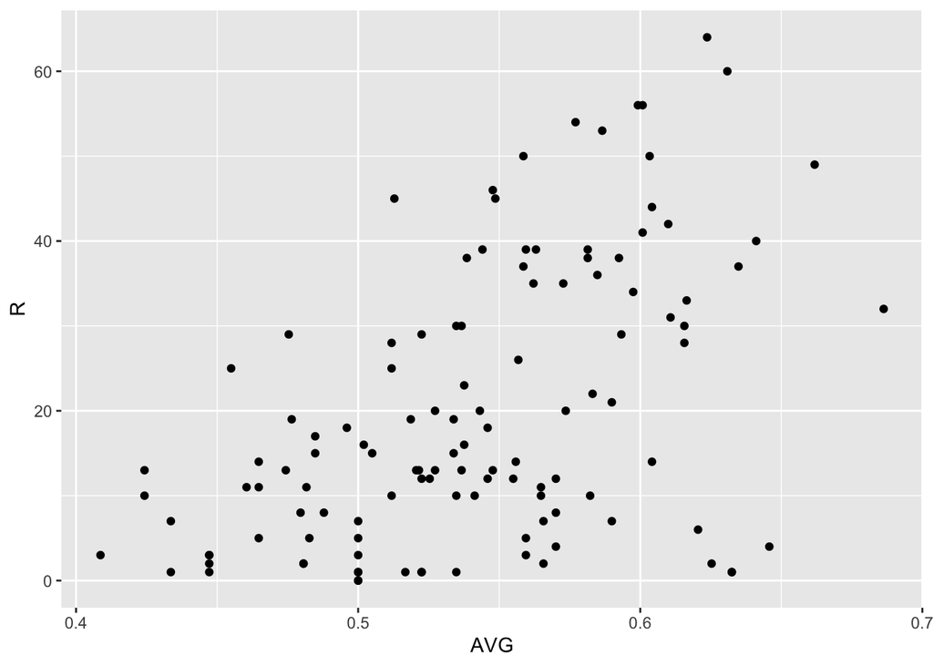

```r
ggplot(data=SAA) + geom_point(aes(y=R, x=AVG))
```

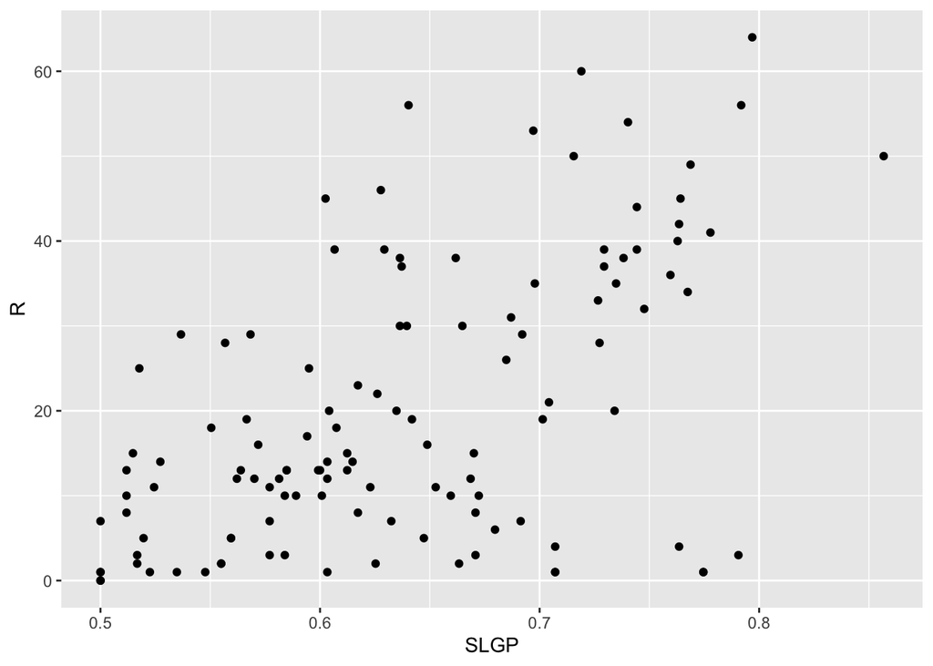

```r
ggplot(data=SAA) + geom_point(aes(y=R, x=SLGP))
```

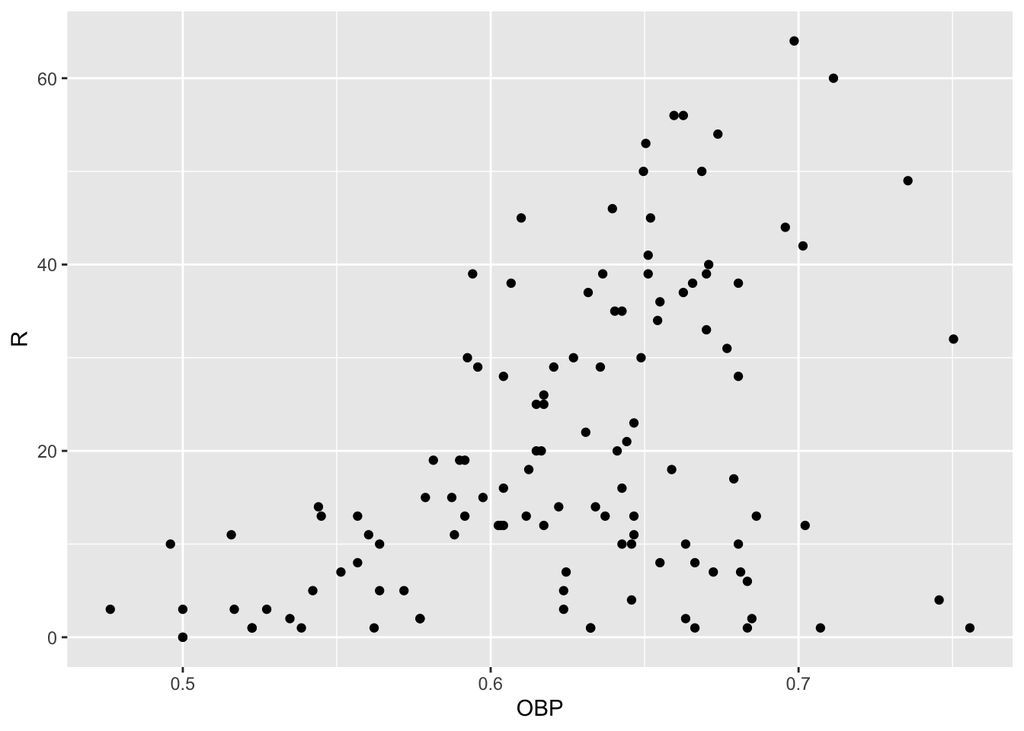

```r
ggplot(data=SAA) + geom_point(aes(y=R, x=OBP))
```

```r
NESCAC <- filter(d3BaseballClean, Team == "Middlebury" | Team == "Tufts" | Team == "Hamilton" | Team == "Colby" | Team == "Amherst" | Team == "Bowdoin" | Team == "Wesleyan" | Team == "Williams" | Team == "Trinity" | Team == "Bates")
view(NESCAC)
```

Visualizing data

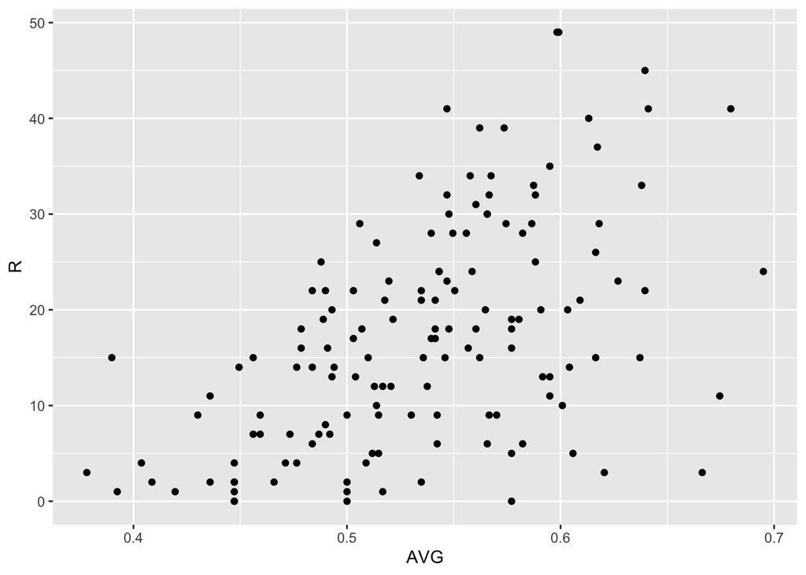

```r
ggplot(data=NESCAC) + geom_point(aes(y=R, x=AVG))
```

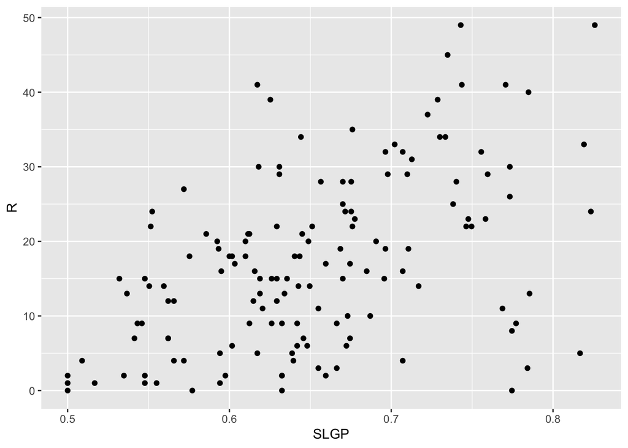

```r
ggplot(data=NESCAC) + geom_point(aes(y=R, x=SLGP))
```

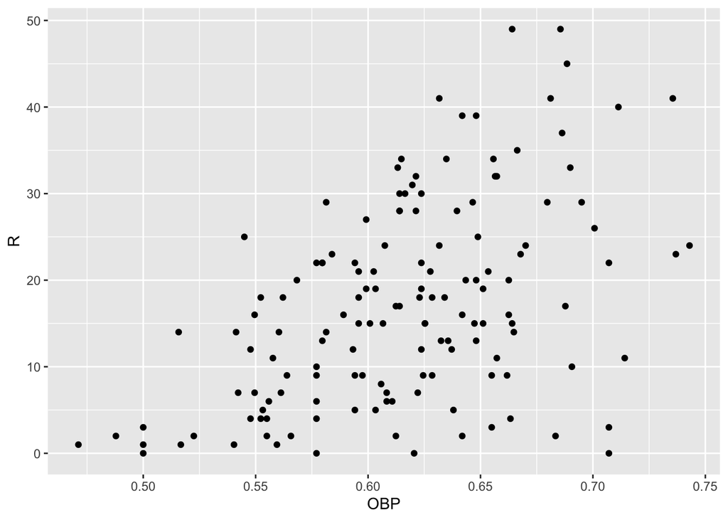

```r
ggplot(data=NESCAC) + geom_point(aes(y=R, x=OBP))
```

## Model

Model with only SAA data

```r
model2 <- lm(R~AVG+SLGP+OBP, data = SAA)
```

Checking diagnostics

[figure not shown]

```r
plot(model, which = 1)
```

[figure not shown]

```r
plot(model, which = 2)
```

```r
plot(model, which = 3)
```

[output not shown]

Model summary

```r
summary(model2)
```

```
##
## Call:
## lm(formula = R ~ AVG + SLGP + OBP, data = SAA)
##
## Residuals:
##     Min      1Q  Median      3Q     Max
## -34.096  -7.083  -0.731   7.979  32.290
##
## Coefficients:
##             Estimate Std. Error t value Pr(>|t|)
## (Intercept)   -72.24      13.79  -5.239 7.22e-07 ***
## AVG            30.07      39.43   0.762 0.447301
## SLGP           76.13      20.62   3.691 0.000341 ***
## OBP            43.98      32.01   1.374 0.172114
## ---
## Signif. codes:  0 '***' 0.001 '**' 0.01 '*' 0.05 '.' 0.1 ' ' 1
##
## Residual standard error: 13.48 on 117 degrees of freedom
## Multiple R-squared:  0.335,  Adjusted R-squared:  0.3179
## F-statistic: 19.65 on 3 and 117 DF,  p-value: 2.207e-10
```

## Model

Model with only NESCAC data

```r
model3 <- lm(R~AVG+SLGP+OBP, data = NESCAC)
```

Checking Diagnostics

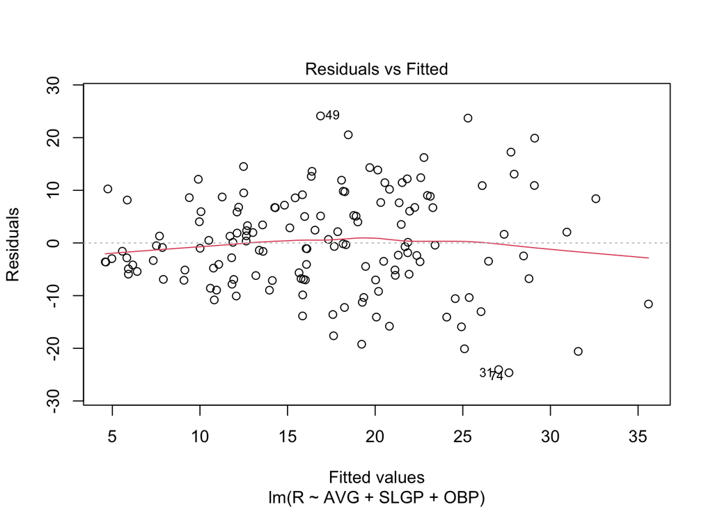

```r
plot(model3, which = 1)
```

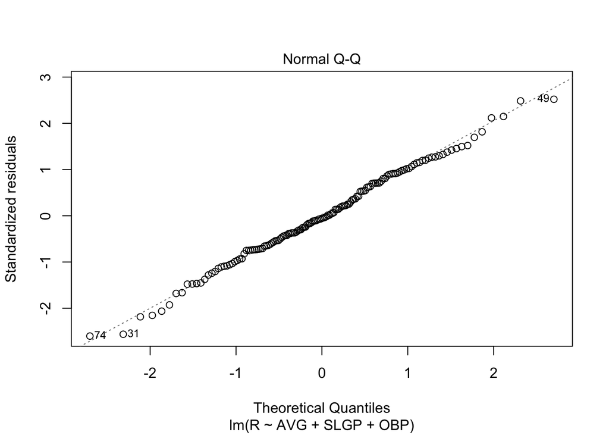

```r
plot(model3, which = 2)
```

```r
plot(model, which = 3)
```

[output not shown]

Model Summary

```r
summary(model3)
```

```
##
## Call:
## lm(formula = R ~ AVG + SLGP + OBP, data = NESCAC)
##
## Residuals:
##      Min       1Q   Median       3Q      Max
## -24.6336  -6.1892  -0.5155   6.7916  24.1199
##
## Coefficients:
##             Estimate Std. Error t value Pr(>|t|)
## (Intercept)  -53.702      9.628  -5.578 1.21e-07 ***
## AVG           49.335     21.117   2.336  0.02088 *
## SLGP          38.210     13.298   2.873  0.00469 **
## OBP           31.694     23.725   1.336  0.18374
## ---
## Signif. codes:  0 '***' 0.001 '**' 0.01 '*' 0.05 '.' 0.1 ' ' 1
##
## Residual standard error: 9.626 on 141 degrees of freedom
## Multiple R-squared:  0.331,  Adjusted R-squared:  0.3167
## F-statistic: 23.25 on 3 and 141 DF,  p-value: 2.75e-12
```

## Results

# Conclusion

From our models, we conclude that instead of generalizing to the entirety of Division III baseball; we see that play styles and the importance of different batting statistics can differ between conferences. Overall, we observe that slugging percentage and batting average are the better predictors in comparison to on-base percentage; although we conjecture that some discrepancies in the data may be playing a part in that observation. However, our findings lead us towards the general statement that pitching in Division III is levels below what you may see at the Division I level, especially in terms of depth of bullpens. Thus, swinging the bat and getting hits is a necessary feature of most Division III offenses, as opposed to walking or getting hit by pitches. There are less strikeouts, making it evident why batting average or slugging percentage would be the most predictive factors in earning more runs.